# Data Center Opposition Movement Profile in the United States

Time trend, geography, partisanship, and socio-economic contexts

Author

Jaewook Lee

Published

July 7, 2026

← Tracker

# Summary

These descriptive figures suggest three early patterns in the tracker, focusing on the United States. First, documented opposition to data center development took off in 2024 and has grown rapidly since then. The 2026 count should be read as partial because the tracker is current through 2026-07-06.

Second, documented local movements appear across 48 states, concentrated in the Midwest: Wisconsin (12 counties), followed by Indiana, Michigan, and North Carolina (10 each), then Virginia, Georgia, and Kentucky (9 each). About a third of all opposition counties fall in the Midwest census region. Counting statewide efforts as well, the tracker spans 49 states; Vermont is the only one with no local case, represented solely by a statewide bill to pause AI data centers. Opposition counties also skew urban and suburban.

Third, the mapped opposition is not confined to one partisan or socio-economic profile. Opposition counties appear across both Democratic- and Republican-leaning places and span a broad range of income levels, though they tend to be higher-income than the national median, consistent with their urban and suburban concentration; recent income growth is similar to the national median. On racial and educational composition, opposition counties tend to fall below the national median on white non-Hispanic share but above it on college attainment, though with spread across all four quadrants. This does not imply that opposition is evenly distributed everywhere, but it does suggest the phenomenon is broader than a single political, economic, or demographic niche.

# Annual Trend

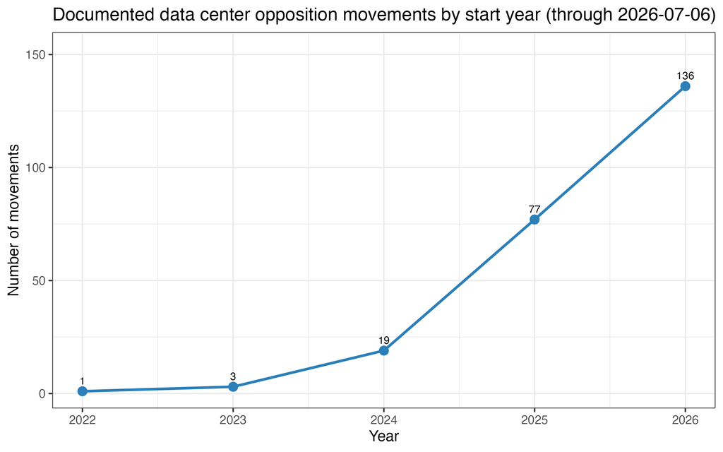

Documented data center opposition movements by start year.

# Where Opposition Happens

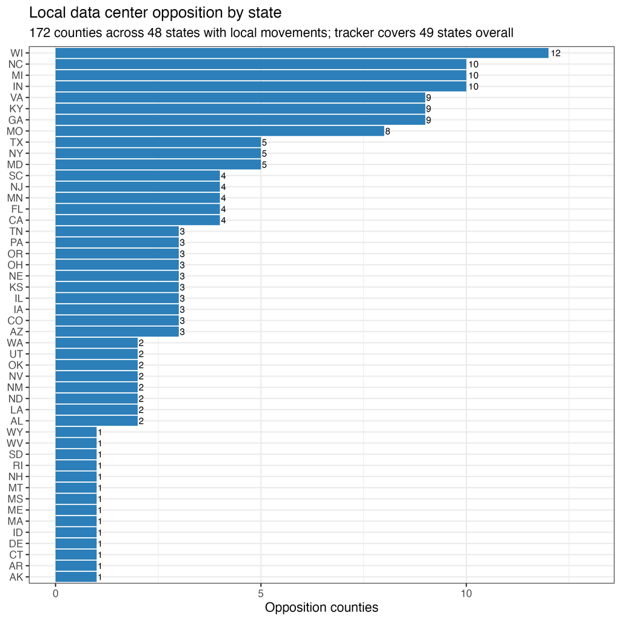

Number of movement counties by state.

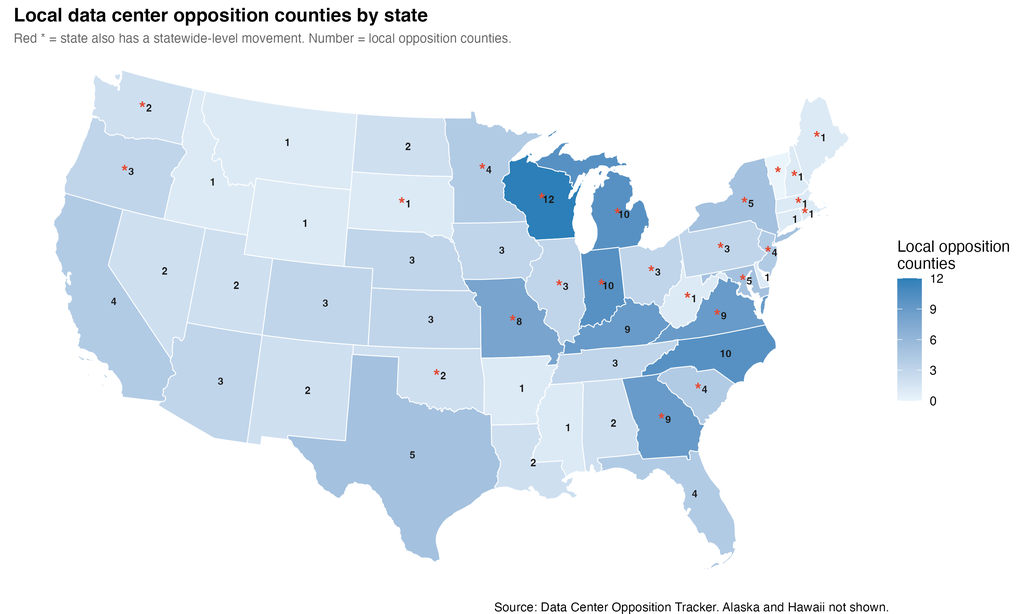

State choropleth map of local opposition counties. Numbers show the count per state; asterisks mark states with at least one statewide-level movement.

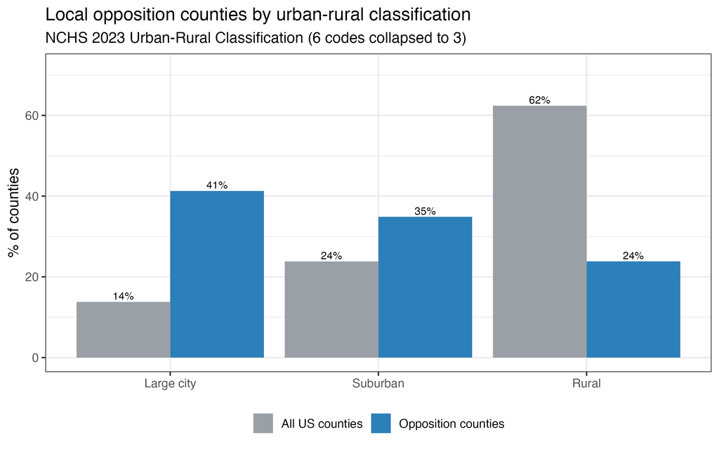

Urban-rural breakdown of opposition counties versus all US counties.

# Income Level and Partisanship

Each chart marks both the national median and the opposition-county median for reference. Opposition counties cluster to the right of the national median, consistent with their higher-income, more urban and suburban profile.

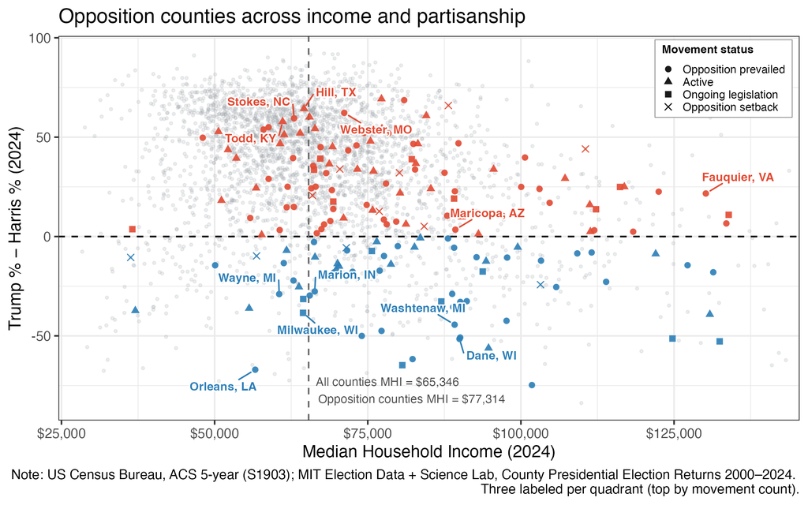

Median household income and 2024 presidential margin.

# Income Growth and Partisanship

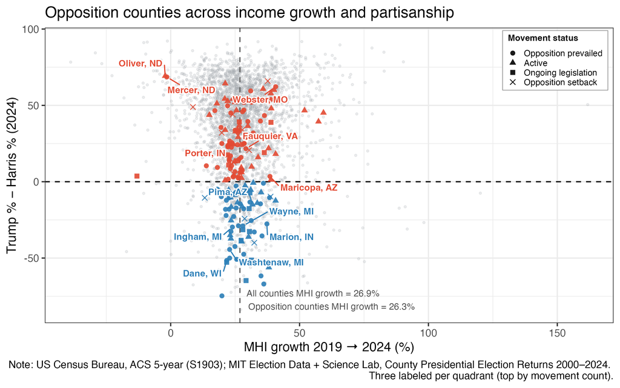

Five-year median household income growth and 2024 presidential margin.

# Race and Educational Attainment

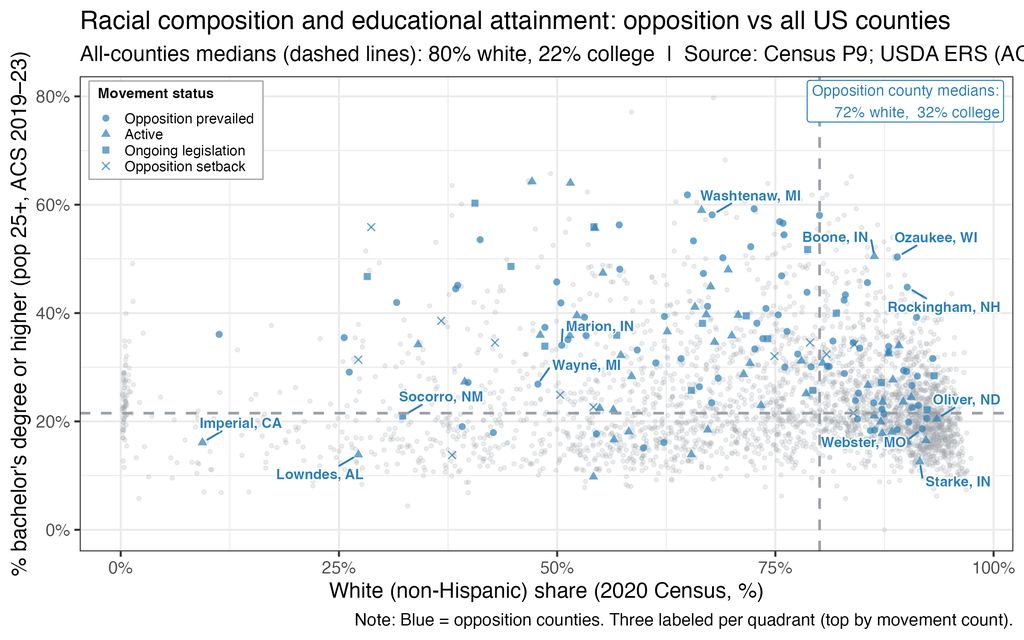

White non-Hispanic share and college attainment: opposition counties versus all US counties.